# Importing and Processing CSV Files

Marc Los Huertos

12/6/2016

## Importing CSV Files

First, we will import the CSV file. In most cases, we don’t need to preprocess the csv files.

```r
#Importing Scripts

file = "/home/CAMPUS/mwl04747/github/Climate_Change_Narratives/Sophie/NewOrleansNOAAdata.csv"
import = read.csv(file)
```

## Checking the Data

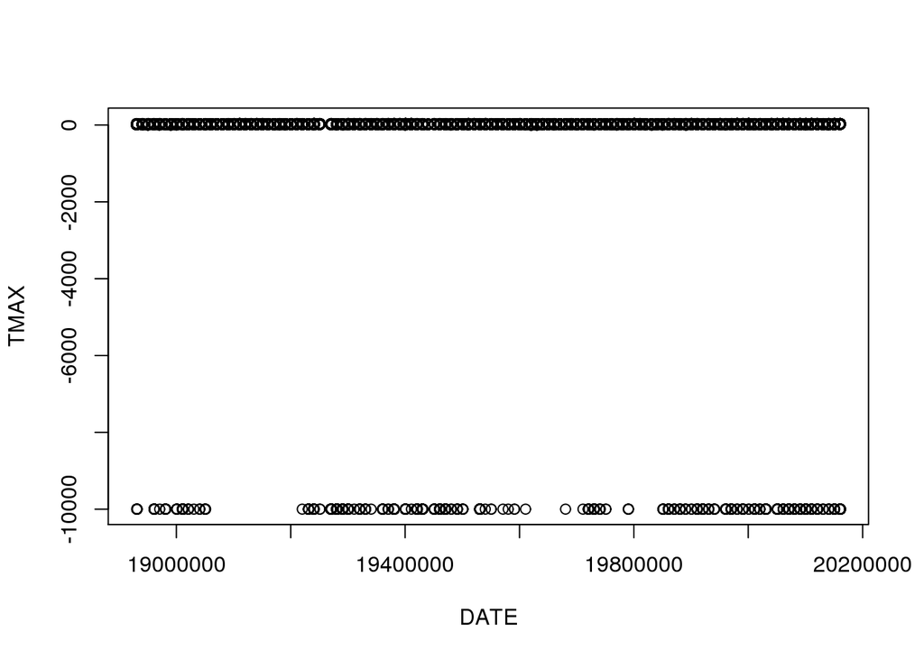

```r
plot(TMAX~DATE, import)
```

What’s going on? What is the deal with the -9999? These are used for missing data. We need to remove them!

```r
import$TMAX[import$TMAX==-9999] = NA
import$TMIN[import$TMIN==-9999] = NA
```

Okay, now we’ll check again, for dates less then Dec. 31, 1913:

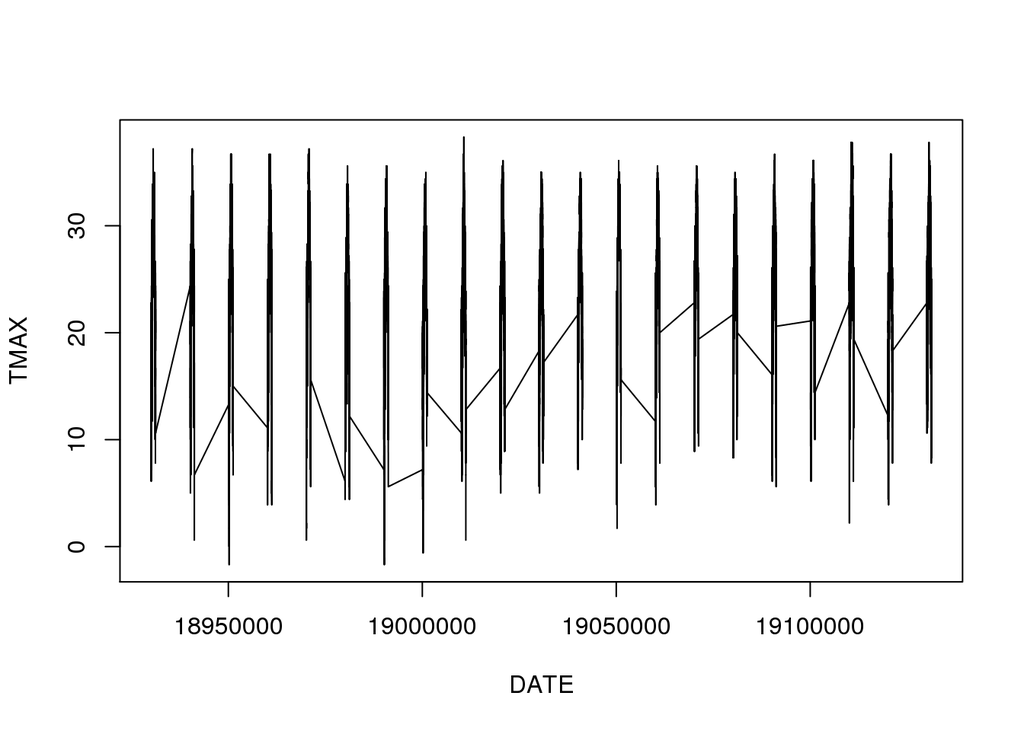

```r
plot(TMAX~DATE, import[import$DATE<19131231,], ty='l')
```

Yikes! What’s wrong? As it turns it the problem is that with how the dates are specified. In particular, the Dec 31 to Jan 1 transition:

19132131 -> 19140101, if you use these as numbers it should be 19131232, 19131232, etc. You see we are missing lots numbers!

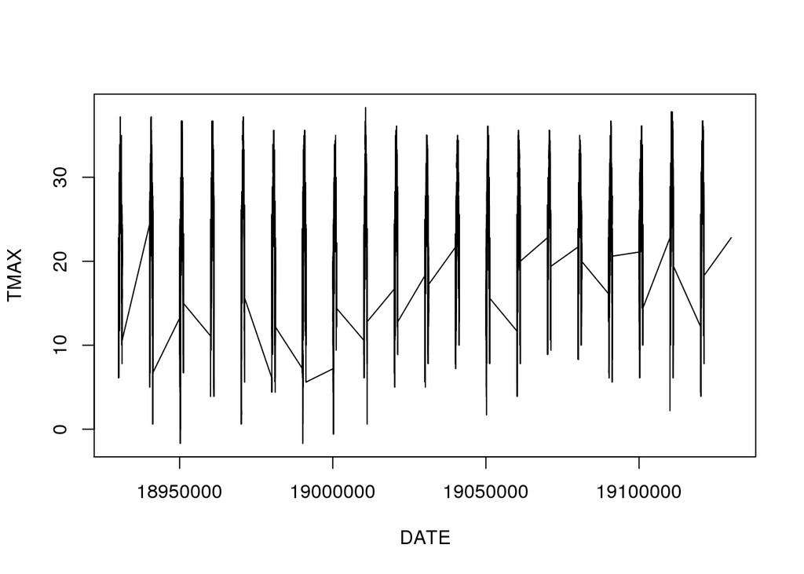

```r
plot(TMAX~DATE, import[import$DATE<19130102,], ty='l')
```

## Fixing the Dates

First, we convert the date a string or character values. Next, we’ll convert the strings to a data format.

```r
strDates <- as.character(import$DATE)
head(strDates)
```

```
## [1] "18930101" "18930102" "18930103" "18930104" "18930105" "18930106"
```

```r
import$NewDate <- as.Date(strDates, "%Y%m%d")
```

## Checking the New Dates

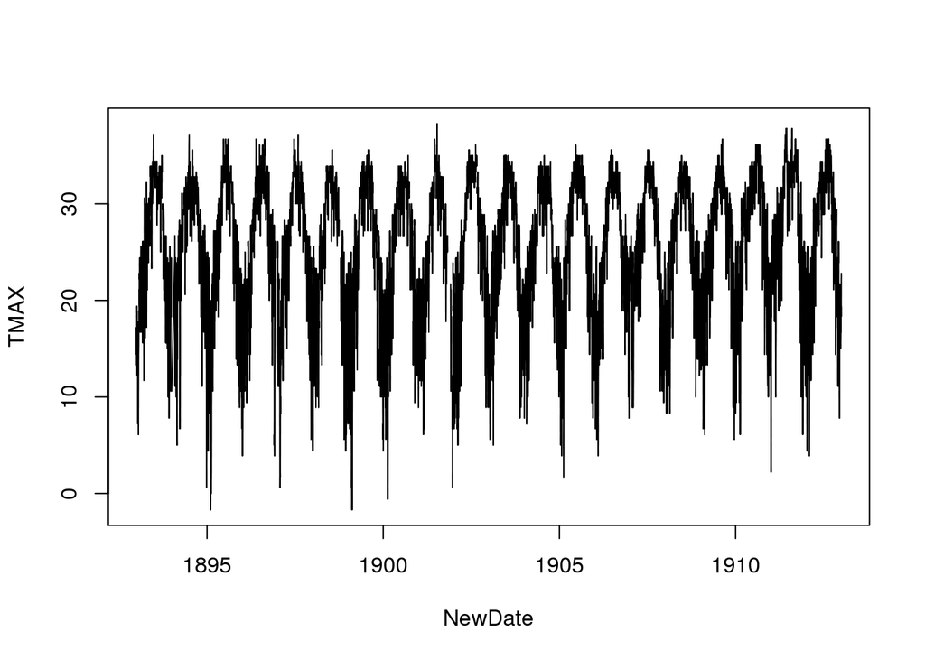

```r
plot(TMAX~NewDate, import[import$DATE<19130102,], ty='l')
```

## A new plot

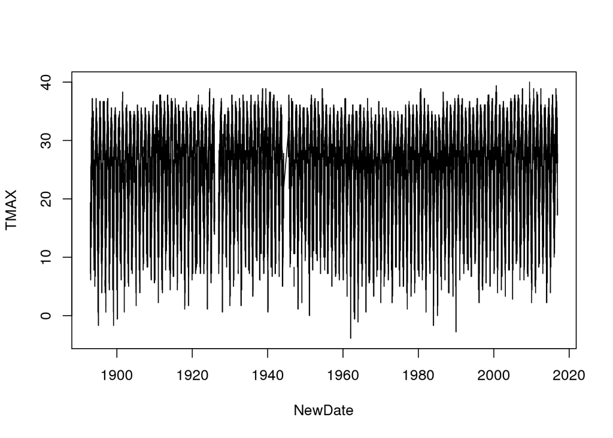

```r
plot(TMAX~NewDate, import, ty='l')
```

## Evaluating the trend

Creating a linear model and then evaluate the rate (slope).

```r
# Linear Model
import.lm <- lm(TMAX~NewDate, data=import)
summary(import.lm)
```

```
##
## Call:
## lm(formula = TMAX ~ NewDate, data = import)
##
## Residuals:
##     Min      1Q  Median      3Q     Max
## -30.033  -4.370   1.157   5.692  13.736
##
## Coefficients:
##              Estimate Std. Error t value Pr(>|t|)
## (Intercept) 2.616e+01  3.617e-02 723.208  < 2e-16 ***
## NewDate     7.539e-06  2.548e-06   2.959  0.00308 **
## ---
## Signif. codes:  0 '***' 0.001 '**' 0.01 '*' 0.05 '.' 0.1 ' ' 1
##
## Residual standard error: 6.932 on 43027 degrees of freedom
##   (1154 observations deleted due to missingness)
## Multiple R-squared:  0.0002035,  Adjusted R-squared:  0.0001803
## F-statistic: 8.758 on 1 and 43027 DF,  p-value: 0.003084
```

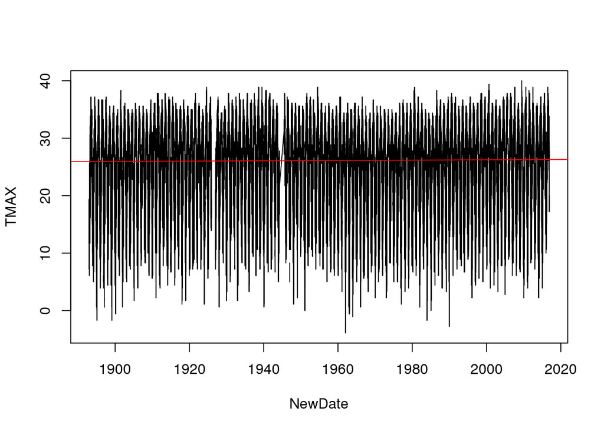

```r
plot(TMAX~NewDate, import, ty='l')
abline(coef(import.lm), col='red')
```

## Time Series

Time series data require specific statistical methods. I started thiking about how to do this in R, but didn’t finish… so this is superfolous for now.

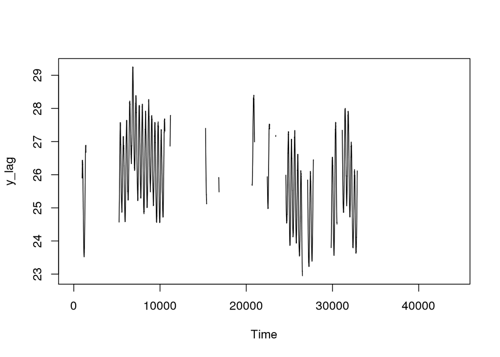

```r
#2.906*10-5 degrees/year or 2.9*10-2 per year.

# Moving Average!
# average of current sample and 19 previous samples (red)
f20 <- rep(1/600, 600)
y_lag <- filter(import$TMAX, f20, sides=1)
plot(y_lag)
```

```r
# Create a time series
Tmax = ts(import$TMAX)
```

## Creating Month and Year Variables

So, let’s figure out how to see how changes happen for individual months.

```r
# Get months
import$Month = months(import$NewDate)
import$Year = format(import$NewDate, format="%Y")
```

### Creating Monthly Means

```r
MonthlyMean = aggregate(TMAX ~ Month + Year, import, mean)

MonthlyMean$YEAR = as.numeric(MonthlyMean$Year)
head(MonthlyMean)
```

```
##      Month Year     TMAX YEAR
## 1    April 1893 27.16000 1893
## 2   August 1893 31.71935 1893
## 3 December 1893 18.41724 1893
## 4 February 1893 21.35357 1893
## 5  January 1893 15.30000 1893
## 6     July 1893 33.51333 1893
```

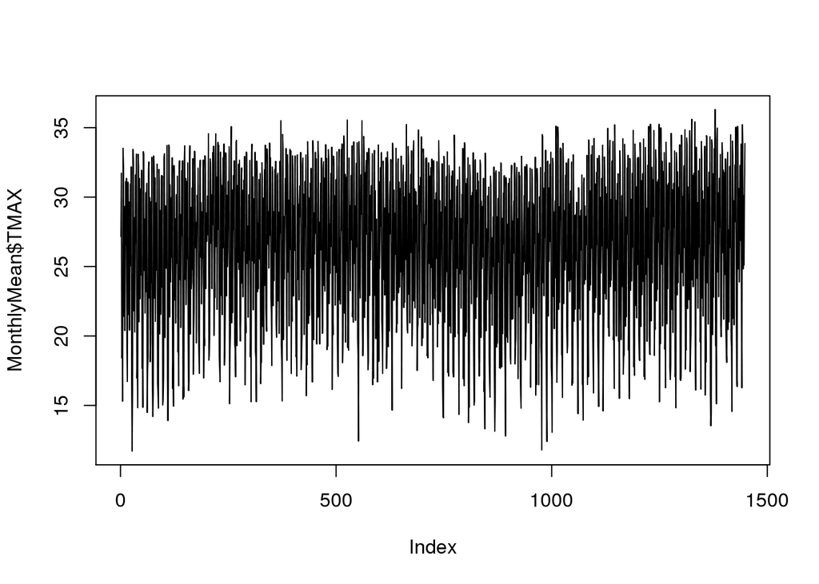

```r
plot(MonthlyMean$TMAX, ty='l')
```

### Selecting for 1 Month – May

Perhaps, we can get a better handle on this stuff if we analyze for just one month at a time – certainly easier to visualize!

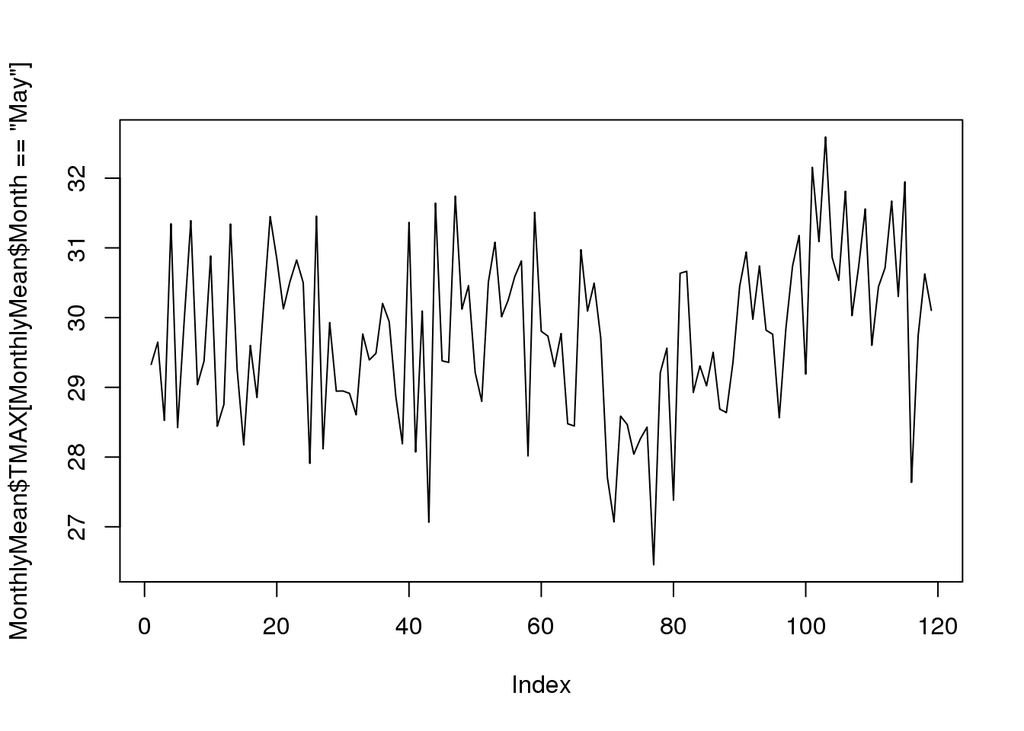

```r
plot(MonthlyMean$TMAX[MonthlyMean$Month=="May"], ty='l')
```

```r
plot(TMAX~YEAR, data=MonthlyMean[MonthlyMean$Month=="May",], ty='l')
May.lm <- lm(TMAX~YEAR, data=MonthlyMean[MonthlyMean$Month=="May",])
summary(May.lm)
```

```
##
## Call:
## lm(formula = TMAX ~ YEAR, data = MonthlyMean[MonthlyMean$Month ==
##     "May", ])
##
## Residuals:
##     Min      1Q  Median      3Q     Max
## -3.4008 -0.7790  0.0120  0.7826  2.5940
##
## Coefficients:
##              Estimate Std. Error t value Pr(>|t|)
## (Intercept) 19.625995   5.954028   3.296   0.0013 **
## YEAR         0.005185   0.003045   1.703   0.0913 .
## ---
## Signif. codes:  0 '***' 0.001 '**' 0.01 '*' 0.05 '.' 0.1 ' ' 1
##
## Residual standard error: 1.204 on 117 degrees of freedom
## Multiple R-squared:  0.02418,    Adjusted R-squared:  0.01584
## F-statistic: 2.899 on 1 and 117 DF,  p-value: 0.0913
```

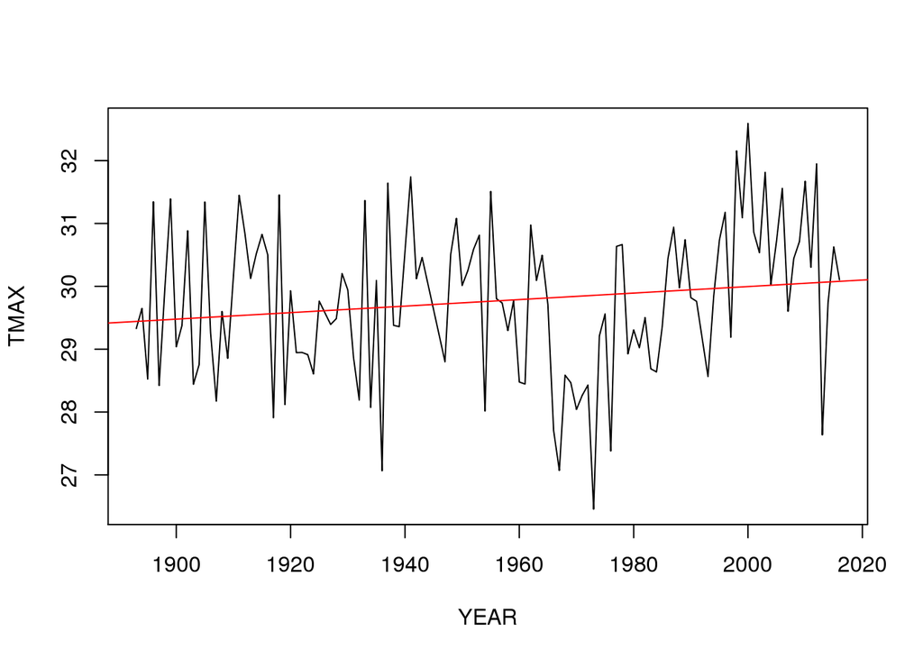

```r
abline(coef(May.lm), col="red")
```

Now, the change is 0.0051852 degress/year or 0.519 degress/100 years (YIKES!) with a probability of 0.0913. Although we can’t reject the null hypothesis, it is worrying!

## Next Steps

I think you should evaluate every month and see what happens. You might also consider looking at the TMIN as well. Could be important!

## Lets try Dec

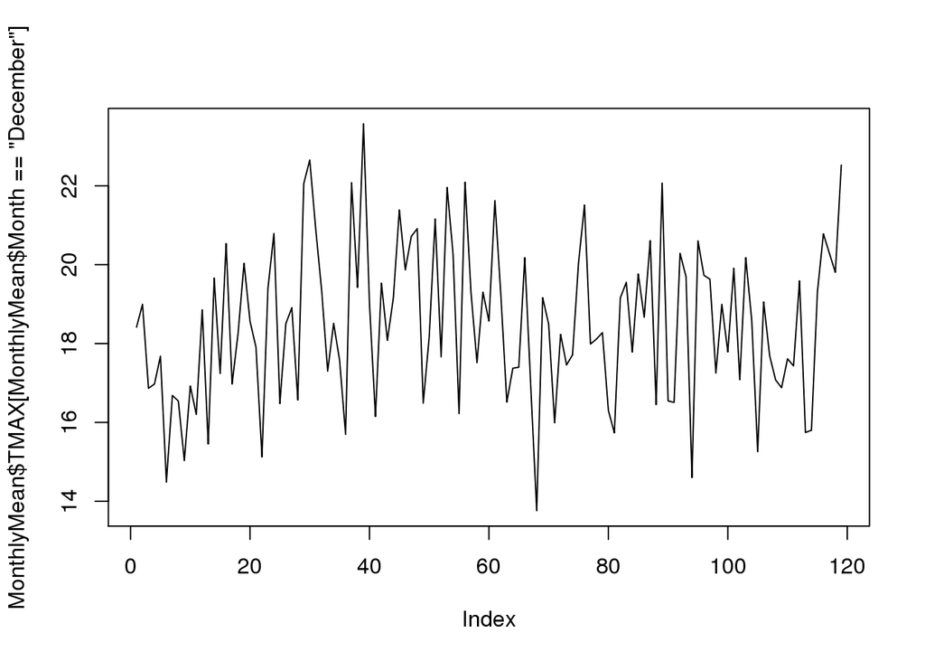

```r
plot(MonthlyMean$TMAX[MonthlyMean$Month=="December"], ty='l')
```

```r
plot(TMAX~YEAR, data=MonthlyMean[MonthlyMean$Month=="December",], ty='l')
Dec.lm <- lm(TMAX~YEAR, data=MonthlyMean[MonthlyMean$Month=="December",])
summary(Dec.lm)
```

```
##
## Call:
## lm(formula = TMAX ~ YEAR, data = MonthlyMean[MonthlyMean$Month ==
##     "December", ])
##
## Residuals:
##     Min      1Q  Median      3Q     Max
## -4.7728 -1.3943  0.0562  1.1955  5.1660
##
## Coefficients:
##              Estimate Std. Error t value Pr(>|t|)
## (Intercept) 10.088843  10.013752   1.007    0.316
## YEAR         0.004302   0.005124   0.840    0.403
##
## Residual standard error: 1.988 on 117 degrees of freedom
## Multiple R-squared:  0.00599,    Adjusted R-squared:  -0.002506
## F-statistic: 0.7051 on 1 and 117 DF,  p-value: 0.4028
```

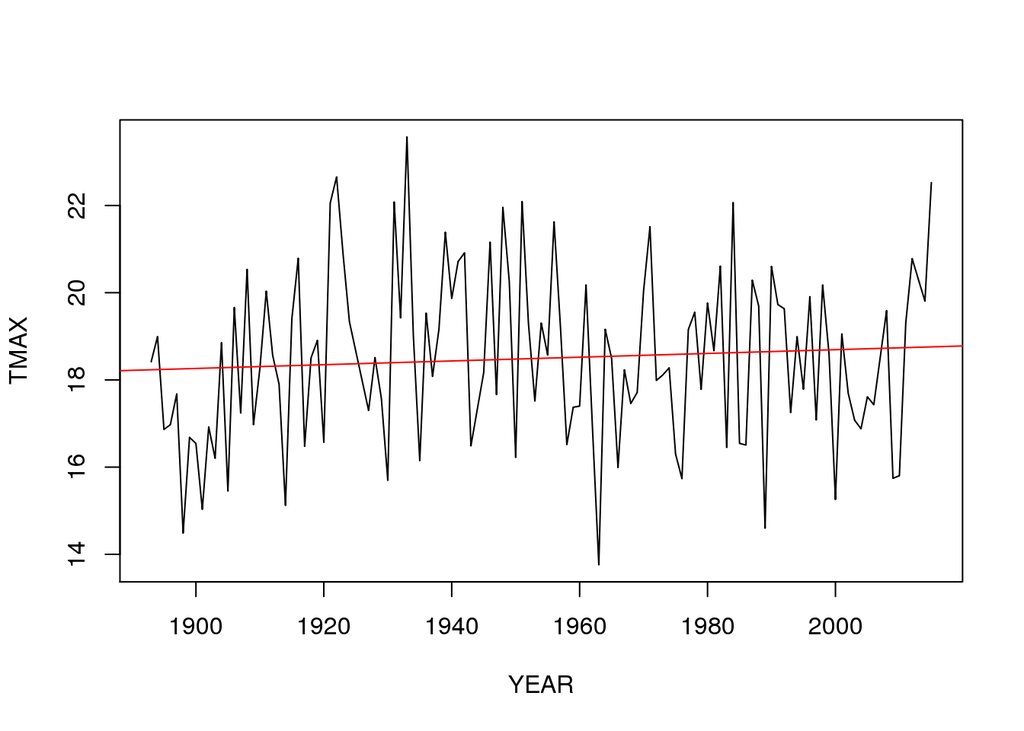

```r
abline(coef(Dec.lm), col="red")
```

## TMIN

1. We create a monthly mean for each month.

```r
MonthlyMeanTMIN = aggregate(TMIN ~ Month + Year, import, mean)

MonthlyMeanTMIN$YEAR = as.numeric(MonthlyMeanTMIN$Year)
head(MonthlyMeanTMIN)
```

```
##      Month Year      TMIN YEAR
## 1    April 1893 16.289655 1893
## 2   August 1893 22.816129 1893
## 3 December 1893  7.160714 1893
## 4 February 1893 12.389286 1893
## 5  January 1893  4.216129 1893
## 6     July 1893 23.635484 1893
```

2. Now we plot the mins, and again, find tons of scatter.

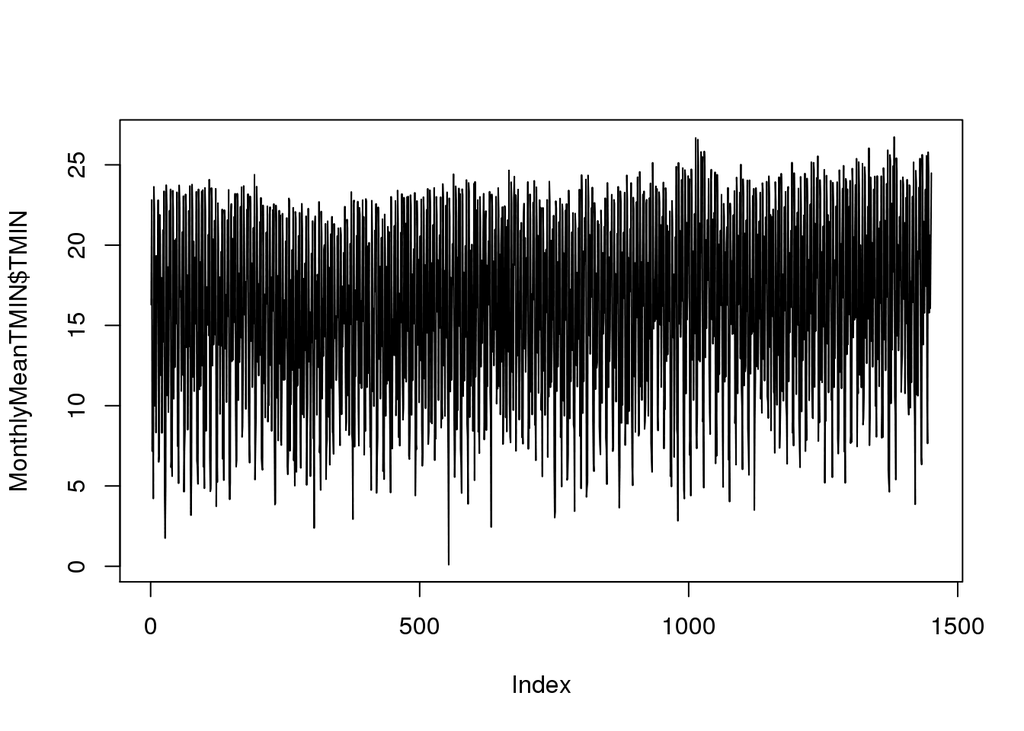

```r
plot(MonthlyMeanTMIN$TMIN, ty='l')
```

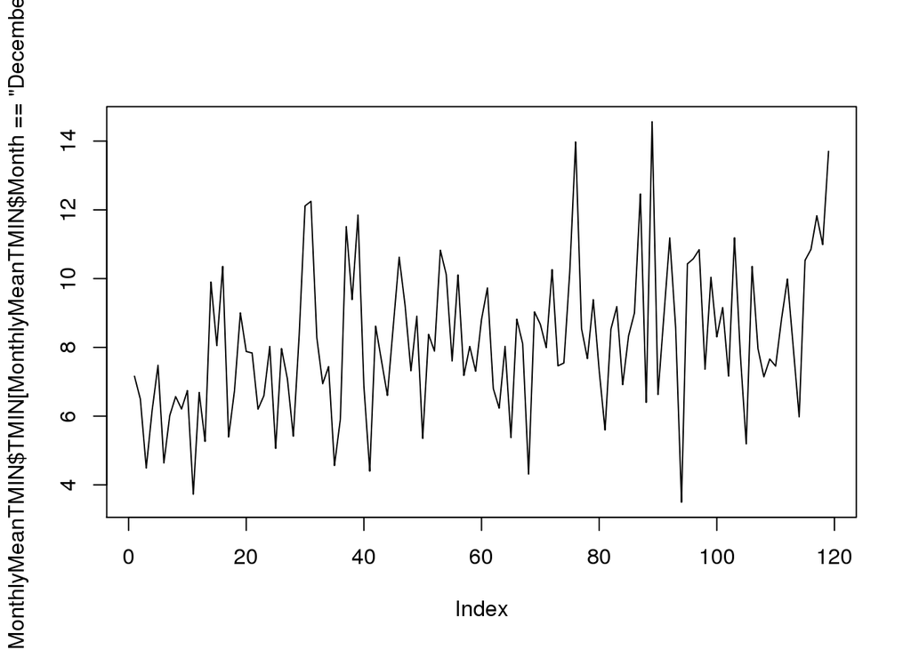

```r
plot(MonthlyMeanTMIN$TMIN[MonthlyMeanTMIN$Month=="December"], ty='l')
```

```r
plot(TMIN~YEAR, data=MonthlyMeanTMIN[MonthlyMeanTMIN$Month=="December",], ty='l')
Dec.lm <- lm(TMIN~YEAR, data=MonthlyMeanTMIN[MonthlyMeanTMIN$Month=="December",])
summary(Dec.lm)
```

```
##
## Call:
## lm(formula = TMIN ~ YEAR, data = MonthlyMeanTMIN[MonthlyMeanTMIN$Month ==
##     "December", ])
##
## Residuals:
##     Min      1Q  Median      3Q     Max
## -5.4490 -1.2880 -0.1926  1.0409  5.7261
##
## Coefficients:
##               Estimate Std. Error t value Pr(>|t|)
## (Intercept) -35.039898  10.258092  -3.416 0.000875 ***
## YEAR          0.022114   0.005249   4.213 4.97e-05 ***
## ---
## Signif. codes:  0 '***' 0.001 '**' 0.01 '*' 0.05 '.' 0.1 ' ' 1
##
## Residual standard error: 2.036 on 117 degrees of freedom
## Multiple R-squared:  0.1317, Adjusted R-squared:  0.1243
## F-statistic: 17.75 on 1 and 117 DF,  p-value: 4.972e-05
```

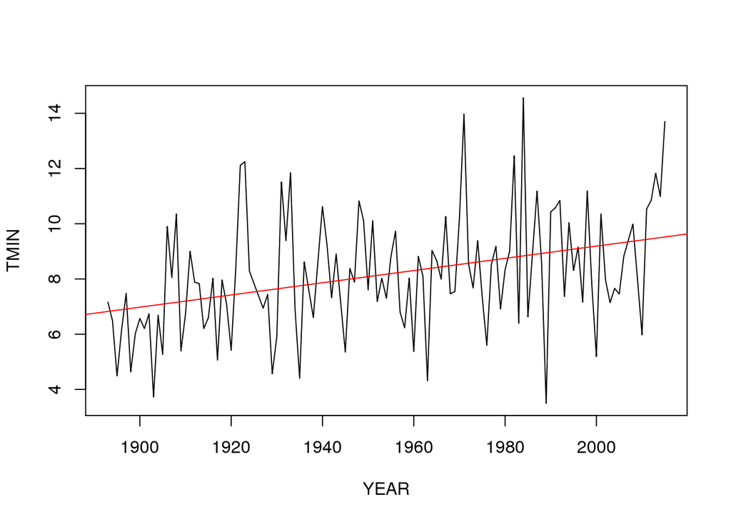

```r
abline(coef(Dec.lm), col="red")
```